# Statistical analysis (main dependent variable)

Brent J. Raiteri (on data from Paolo Tecchio’s hybrid 3D fascicle tractography approach)  
2026-02-27

## Muscle volume from DTI

Fixed effects were fitted using a linear mixed-effects model. Model-based standard errors and p-values are presented. Sandwich variance estimation-based standard errors and p-values were also produced; these do not assume normality of the data.

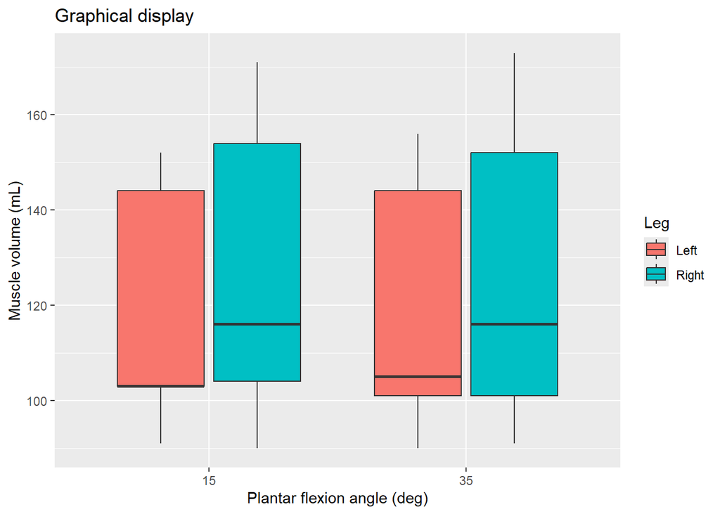

## Fixed-effects model with interaction

This fixed-effects model fits the factors plantar flexion angle and leg with random intercepts and fixed slopes and a fixed angle x leg interaction.  
We first compared fitting the model by REML vs. ML, and REML resulted in a better fit:

```
## $statistics
##                      aic     bic bayes.factor
## interaction_REML 133.714 139.688     7778.804
## interaction_ML   151.632 157.606        0.000
##
## $predicted_differences
##   0%  25%  50%  75% 100%
##    0    0    0    0    0
```

## Model summary

```
## Linear mixed model fit by REML. t-tests use Satterthwaite's method [
## lmerModLmerTest]
## Formula: voldti ~ angle * leg + (1 | id)
##    Data: d
##
## REML criterion at convergence: 121.7
##
## Scaled residuals:
##      Min       1Q   Median       3Q      Max
## -1.40983 -0.62568 -0.02357  0.53078  1.39709
##
## Random effects:
##  Groups   Name        Variance Std.Dev.
##  id       (Intercept) 971.13   31.163
##  Residual              21.45    4.631
## Number of obs: 20, groups:  id, 5
##
## Fixed effects:
##             Estimate Std. Error      df t value Pr(>|t|)
## (Intercept)  118.600     14.089   4.133   8.418 0.000944 ***
## angle2         0.600      2.929  12.000   0.205 0.841133
## leg2           8.400      2.929  12.000   2.868 0.014150 *
## angle2:leg2   -1.000      4.143  12.000  -0.241 0.813319
## ---
## Signif. codes:  0 '***' 0.001 '**' 0.01 '*' 0.05 '.' 0.1 ' ' 1
##
## Correlation of Fixed Effects:
##             (Intr) angle2 leg2
## angle2      -0.104
## leg2        -0.104  0.500
## angle2:leg2  0.074 -0.707 -0.707
```

## Model- & sandwich-based standard errors and p-values

The full cluster-robust variance-covariance matrix was calculated, which includes the variances (SEs) and covariances (how much the estimates correlate with each other):

```
## Model- & sandwich-based standard errors and p-values
```

```
## Click on the arrow for sandwich-based p-values.
```

```
## # A tibble: 4 × 6
##   term        estimate `Model-based s.e.` `Model-based p-value` `Sandwich s.e.`
##   <chr>          <dbl>              <dbl>                 <dbl>           <dbl>
## 1 (Intercept)    119.               14.1            0.000000754          12.3
## 2 angle2           0.6               2.93           0.841                 1.08
## 3 leg2             8.4               2.93           0.0124                3.74
## 4 angle2:leg2     -1                 4.14           0.813                 0.775
##   `Sandwich p-value`
##                <dbl>
## 1           0.000640
## 2           0.607
## 3           0.0878
## 4           0.266
```

## Estimated marginal means

Estimated marginal means (EMMs) for the fixed-effects model with a fixed angle x leg interaction are reported below, which explicitly use cluster-robust standard errors (accounting for non-independent data or heteroskedasticity). This approach was used to ensure that the confidence intervals and subsequent p-values for the EMMs are more accurate and reliable.

```
## leg = 1:
##  angle emmean   SE   df lower.CL upper.CL
##  1        119 12.3 4.13     85.0      152
##  2        119 13.0 4.13     83.7      155
##
## leg = 2:
##  angle emmean   SE   df lower.CL upper.CL
##  1        127 15.3 4.13     85.0      169
##  2        127 15.5 4.13     84.0      169
##
## Degrees-of-freedom method: satterthwaite
## Confidence level used: 0.95
```

```
##  angle emmean   SE   df lower.CL upper.CL
##  1        123 13.7 4.04     84.8      161
##  2        123 14.2 4.04     83.6      162
##
## Results are averaged over the levels of: leg
## Degrees-of-freedom method: satterthwaite
## Confidence level used: 0.95
```

```
##  contrast        estimate    SE df t.ratio p.value
##  angle2 - angle1      0.1 0.927 12   0.108  0.9159
##
## Results are averaged over the levels of: leg
## Degrees-of-freedom method: satterthwaite
```